# Sampling Distributions and CIs

Stat 241

## Some important words

- **Population** – the people/animals/objects we want to know about.
- **Sample** – the people/animals/objects we have data about.
- **Parameter** – a number describing (a feature of) the population.
- **Statisticd** – a number describing (a feature of) the sample.
- **Estimand** – a parameter we number we want to know (at least approximately).
- **Estimate** – a numerical approximation to the estimand based on a particular data set.
- **Estimator** – a random variable showing the distribution of estimtes over all possible random samples.

## Sampling Distributions

A **sampling distribution** is the distribution of some number computed from a random sample. This is a bit more general than an estimator, because we might be using this number for something other than making an estimate, but it is basically the same idea.

[This online app](http://onlinestatbook.com/stat_sim/sampling_dist/index.html) illustrates these ideas nicely.

## Sampling Distribution for the Sample Mean

If we have an iid random sample from a population with mean $\mu$ and standard deviation $\sigma$, then

$$\overline{X} \approx {\sf Norm}(\mu, \frac{\sigma}{\sqrt{n}})$$

provided the sample size is large enough. The approximation

- is exact if the population is exactly normal.
- is better if the population distribution is more like a normal distirbution
- is better if the sample size is larger.

### Standard Error

The standard deviation of a sampling distribution is called the **standard erorr** (SE). So the standard errror for the mean is

$$SE = \frac{\sigma}{\sqrt{n}}$$

### Difference bewteen $\overline{X}$ and $\mu$.

$$\overline{X} - \mu \approx {\sf Norm}(0, \frac{\sigma}{\sqrt{n}})$$

This means we know something about how close our estimate (sample mean) is likely to be to the estimand (population mean).

- $\approx 68$% of sample means are within 1 $SE$ of the population mean
- $\approx 95$% of sample means are within 2 $SE$ of the population mean

In other words

$$\operatorname{P}( |\overline{X} - \mu| \le 2SE) \approx 0.95$$
Since sample mean $\overline{X}$ is usually this close to the population mean $\mu$, the population mean $\mu$ will usually be this close to the sample mean $\overline{X}$. This leads to the idea of a **confidence interval**.

$$\operatorname{P}( \overline{X} - 2SE \le \mu \le \overline{X} + 2 SE) \approx 0.95$$

so we will call the interval
$$(\overline{x} - 2 SE, \overline{x} + 2 SE)$$
the 95% confidence interval for $\mu$. Notice the change from $\overline{X}$ (estimator) to $\overline{x}$ (estimate). We won’t know for any particular confidence interval whether $\mu$ is in the interval, but we know that the estimand is in 95% of the intervals we create this way.

Because this interval is symmetric, it is often written another way:

$$\overline{x} \pm 2 SE$$

If we want a higher coverage rate, we can increase the number 2 to something larger. If we are satisfied with a smaller coverage rate, we can decrease 2 to something smaller. The number we use is called the **critical value**. So more generally our formula for a confidence interval for $\mu$ (population mean) is

$$\overline{x} \pm (\mbox{critical value}) SE$$

Because we get this critical value from a normal (z) distribution, we will write this as

$$\overline{x} \pm z_* SE$$

### Examples

**1.** Determine the critical value to use for 90%, 95%, and 98% confidence intervals.

**2.** If the sample of size $n = 25$ has a mean of $\overline{x} = 10.5$ and the population has a standard deviation of $\sigma = 2$, what are the 90%, 95%, and 98% confidence intervals for $\mu$?

## A problem and a solution

There is a problem with the calculations we have been doing: We almost never have the information we need to do them. In particular, it is not reasonable to expect to know the standard deviation of a population if we dont’ know the mean. The solution?

- Estimate the population standard deviation ($\sigma$) with the sample standard deviation ($s$).

But this brings up another problem. Now the sampling distribution won’t be approximately normal, it will have a different shape. That shape is also symmetric and bell-shaped, but it is a little “fatter”, because their is additional variability due to our estimating $\sigma$. The right distribution to use is called a **t-distribution**.

So our formula for the confidence interval for $\mu$ will be

$$\overline{x} \pm (\mbox{critical value}) SE
=
\overline{x} \pm t_* SE$$

and we will use `qt()` rather than `qnorm()` to get the critical value.

### T-distibutions

T-distirbutions have a parameter called **degrees of freedom**. The larger the degrees of freedom, the more the t-distribution is like a standard normal distribution.

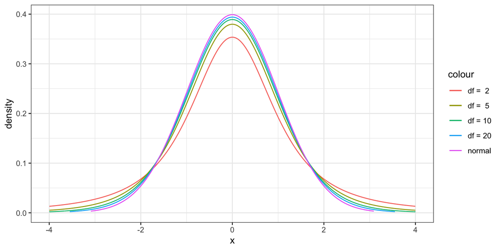

```r
gf_dist("t", df = 2, color = ~ "df =  2") %>%
gf_dist("t", df = 5, color = ~ "df =  5") %>%
gf_dist("t", df = 10, color = ~ "df = 10") %>%
gf_dist("t", df = 20, color = ~ "df = 20") %>%
gf_dist("norm", color = ~ "normal") %>%
  gf_lims(x = c(-4, 4))
```

When we compute a confidence interval for a mean, we use $df = n - 1$ for our degrees of freedom.

### Examples

**3.** Determine the critical value to use for 90%, 95%, and 98% confidence intervals – this time using a t-distribution.

**4.** If the sample of size $n = 25$ has a mean of $\overline{x} = 10.5$ and we don’t know the population standard deviation $\sigma$, what are the 90%, 95%, and 98% confidence intervals for $\mu$?

### When does this work well?

The t-based confidence intervals work better when

- sample size is large
- population is unimodal and symmetric

The smaller the sample size or the more the population deviates from a normal distribution, the less reliable the confidence intervals will be. Generally, things work pretty well for samples of size 30 or more as long as the distribution is unimodal. As sample sizes get smaller, we want to be more and more sure that the population is approximately normal. Of course, we will have less and less data to check with, so we may need to rely on information from other similar studies, or find a different method.

**Outliers** can have a large impact on both the sample mean and sample standard deviation, so when outliers are present in a small sample, we likely need to find a different method (or figure out if something is unusual about that outlier).

## More practice

**1.** A sample of size 100 has a mean of 4.2 and standard deviation of 1.3. Find the 95% and the 99% confidence interval for the population mean.

**2.** The contents of 50 12-ounce cans of Coke Zero were measured. The average contents of those cans was 12.05 ounces with a standard deviation of 0.1 ounces.

1. Based on this data, compute the 95% CI for the average of all 12 ounce cans of Coke Zero.
2. Based on this confidence interval, are you confident that, on average, 12 ounce cans of Coke Zero contain at least 12 ounces of soda?

**3.** The data-frame morley contains measurement of the speed of light in the column Speed. We can consider this data to be a random sample of size 100 of all possible measures of the speed of light.

1. What are the units on the measurements? Use `?morley` to find out. (It won’t be what you would guess without looking.)
2. Use these data to find a 95% CI for the average of all possible measurements. And convert the answer into more natural units.

## What does a confidence interval mean?

Confidence intervals are easier to create (it’s just a bit of algebra or using software) than to understand. The **confidence level** (95%, for example) is the percentage of random samples that produce an interval that **covers** the estimand.

A confidence interval procedure “works” when the coverage rate is equal to the stated confidence level. The procedure we have learned “works” perfectly for a normal distribution and works very well when sample sizes are large or for smaller sample sizes as long as the they are unimodal and roughly symmetric (ie, similar to a normal distribution.) But for small sample sizes from strongly skewed distributions, the confidence level and coverage rate might not match. In particular, the coverage rate might not be as high as is claimed. So for smaller samples, we need to do soem extra thinking about what the shape of the population might be.

To see this illustrated, look at [the illustrative figure in our book on page 120](https://rpruim.github.io/Engineering-Statistics/book/Stat241-Notes.pdf#page=120).

## Automating t-based confidence intervals using R

If we have access to the data and not just to summary statistics, R can do all the work for us, computing the sample mean, sample standard deviation, sample size, degrees of freedom, and critical value and putting the information together to create our confidence interval. All we need to provide is

- the variable containing the sample data,
- the data set that includes the variable,
- our desired level of confidence.

**Example:** The `mass` variable in the `Dimes` data frame contains the masses of a random sample of dimes. Use it to find the 90%, 95%, and 99% CI’s for the average mass of all dimes.

We could do this “by hand” using summary information:

```r
df_stats( ~ mass, data = Dimes)
```

```
##   response  min   Q1 median   Q3 max mean     sd  n missing
## 1     mass 2.21 2.24   2.26 2.27 2.3 2.26 0.0221 30       0
```

But we can also automate the whole process using `t.test()`. The `t.test()` function gives us more output that we need just now, but we can use `confint()` to grab just the confidence interval.

```r
## full output -- you should be able to locate the CI
t.test( ~ mass, data = Dimes, conf.level = .90)
```

```
##
##  One Sample t-test
##
## data:  mass
## t = 560, df = 29, p-value <2e-16
## alternative hypothesis: true mean is not equal to 0
## 90 percent confidence interval:
##  2.25 2.27
## sample estimates:
## mean of x
##      2.26
```

```r
# get just the interval using %>%
t.test( ~ mass, data = Dimes, conf.level = .95) %>% confint()
```

```
##   mean of x lower upper level
## 1      2.26  2.25  2.27  0.95
```

```r
# wrapping one function in the other -- equivalent to using %>%
confint(t.test( ~ mass, data = Dimes, conf.level = .99))
```

```
##   mean of x lower upper level
## 1      2.26  2.25  2.27  0.99
```

## What if the underlying population isn’t normal? Robustness

1. For normal distributions, t-based CI’s are always good, even for small samples.
2. For $15 \le n \le 40$, t-based CI’s are acceptable if the distribution is unimodal and not strongly skewed.
3. For $n > 40$, t-based CI’s are generally acceptable if the distribution is unimodal.
4. Beware of outliers.

## Estimating population proportions

**Example:** We want to estimate the proportion of registered voters in Michigan that have a favorable view of Governor Whitmer The population parameter of interest is the population proportion $p$ (proportion of the population that have a favorable view of Whitmer.)

Suppose we poll a random sample of $n$ registered voters and measure the sample proportion

$$\hat p = \mbox{proportion of the sample with a favorable view of Whitmer}$$

Is a good estimate of $p$? We don’t know (yet). Can we use $\hat p$ to construct a CI estimate for p? Yes. We just need to know the sampling distribution for $\hat p$.

Let $X_i$ be the random variable that has the value 1 if voter $i$ has a favorable view and has the value 0 otherwise. Here is a probability table for $X_i$:

| value of $X_i$ | 0 | 1 |
| --- | --- | --- |
| probability | $1-p$ | $p$ |

What are the mean, variance, and standard deviation for this random variable?

$\operatorname{E}(X_i) = 0 \cdot (1-p) + 1 \cdot p = p$

$\operatorname{E}(X_i^2) = 0^2 (1-p) + 1^2 (1-p) = p$

$\operatorname{Var}(X_i) = \operatorname{E}(X_i^2) - \operatorname{E}(X_i)^2 = p - p^2 = p(1-p)$

$\operatorname{SD}(X_i) = \sqrt{p(1-p)}$

The sample proportion is
$$\hat p
= \frac{\mbox{number favorable}}{\mbox{total number surveyed}}
= \frac{X_1 + X_2 + \cdots X_n}{n} = \overline{X}$$
Even though the distribution of each $X_i$ is nothing like a normal distribution (in fact, it is ${\sf Binom}(1, p)$) the Central Limit Theorm tells us that

$$\hat p = \overline X \approx {\sf Norm}\left( p, \sqrt{\frac{p (1-p)}{n}}\right)$$
So our confidence interval should be

$$\begin{align*}
\mbox{estimate} &\pm \mbox{critical value} \cdot SE
\\
\hat p & \pm z_* \sqrt{\frac{\hat p (1 - \hat p)}{n}}
\end{align*}$$

Things to note:

- Our sample needs to be quite large for this approximation to work because the ${\sf Binom}(1, p)$ distribution is very different from a normal distribution. A commonly used rule of thumb is that we should have at least 10 success and 10 failures in the sample in order to use this method.
- We don’t need to use a t-distribution here. But we do use $\hat p$ in our (estimated) standard error.
- There are better ways to compute a confidence interval for a proportion.
  - One of these uses a binomial distribution instead of a normal distribution. That’s harder to work with, but the distribution is exactly correct instead of only approximately correct. `binom.test()` will do this.
  - One of these makes an adjustment in the normal approximation because normal distributions are continuous and binomial distributions are discrete. This is called the “continuity correction”. `prop.test()` will do this by default, but you can turn off the continuity correction if you like.
  - For small sample sizes, the margin of error is typically quite large – perhaps too large to be useful.

## More Practice

**6.** Company B receives a large shipment of parts from Company A. Company B accepts the fact that any large shipment of parts will contain some defective parts. It is willing to accept a shipment that it is confident contains ar most 10% defective parts. It examines 200 randomly selected parts from the shipment and finds that 15 of them are defective. Calculate the 95% CI for the proportion of all parts in the shipment that are defective. Based on this CI, should Company B be confident that the defective rate for the entire shipment is at most 10%?

**7.** A poll taken at the end of August, 2017, of 600 registered Michigan voters produced 246 respondents that approved of Governor Snyder. Find the 95% CI for the proportion of all registered Michigan voters who approved of the governor August, 2017.

**8.** How large must the sample size be to guarantee that a 95% confidence interval for a proportion will have a margin of error at most $\pm 3$%? Under what conditions might a smaller sample size suffice?

**9.** Redo the dimes example “by hand”.

**10.** A Gallup poll of 3500 people produced a approval rating for President Obama of 50%. Assuming the confidence level is 95%, what is the margin of error for this poll?